# An Exploratory Analysis of Udacity’s Curated White Wine Data Set

Bilal Arshad Chaudhry

November 23, 2018

# 1. Introduction

The EDA of this particular dataset is part of the Data Analyst NanoDegree’s section on Exploratory Data Analysis using R.

The data set is of white Vinho Verde wine samples, from the north of Portugal. The goal of the dataset is to model wine quality based on physicochemical tests, which can be found [here](http://archive.ics.uci.edu/ml/datasets/wine+quality).

### Data Set Attribute Information:

1. Fixed Acidity
2. Volatile Acidity
3. Citric Acid
4. Residual Sugar
5. Chlorides
6. Free Sulfur Dioxide
7. Total Sulfur Dioxide
8. Density
9. pH
10. Sulphates
11. Alcohol
12. Quality - output variable based on sensory data (score between 0 and 10)

# 2. Basic Exploration of the Data Set

We shall begin our analysis by displaying the variables in the dataset and summary statistics:

```
##  [1] "fixed.acidity"        "volatile.acidity"     "citric.acid"
##  [4] "residual.sugar"       "chlorides"            "free.sulfur.dioxide"
##  [7] "total.sulfur.dioxide" "density"              "pH"
## [10] "sulphates"            "alcohol"              "quality"
```

```
## 'data.frame':    4898 obs. of  12 variables:
##  $ fixed.acidity       : num  7 6.3 8.1 7.2 7.2 8.1 6.2 7 6.3 8.1 ...
##  $ volatile.acidity    : num  0.27 0.3 0.28 0.23 0.23 0.28 0.32 0.27 0.3 0.22 ...
##  $ citric.acid         : num  0.36 0.34 0.4 0.32 0.32 0.4 0.16 0.36 0.34 0.43 ...
##  $ residual.sugar      : num  20.7 1.6 6.9 8.5 8.5 6.9 7 20.7 1.6 1.5 ...
##  $ chlorides           : num  0.045 0.049 0.05 0.058 0.058 0.05 0.045 0.045 0.049 0.044 ...
##  $ free.sulfur.dioxide : num  45 14 30 47 47 30 30 45 14 28 ...
##  $ total.sulfur.dioxide: num  170 132 97 186 186 97 136 170 132 129 ...
##  $ density             : num  1.001 0.994 0.995 0.996 0.996 ...
##  $ pH                  : num  3 3.3 3.26 3.19 3.19 3.26 3.18 3 3.3 3.22 ...
##  $ sulphates           : num  0.45 0.49 0.44 0.4 0.4 0.44 0.47 0.45 0.49 0.45 ...
##  $ alcohol             : num  8.8 9.5 10.1 9.9 9.9 10.1 9.6 8.8 9.5 11 ...
##  $ quality             : int  6 6 6 6 6 6 6 6 6 6 ...
```

```
##  fixed.acidity    volatile.acidity  citric.acid     residual.sugar
##  Min.   : 3.800   Min.   :0.0800   Min.   :0.0000   Min.   : 0.600
##  1st Qu.: 6.300   1st Qu.:0.2100   1st Qu.:0.2700   1st Qu.: 1.700
##  Median : 6.800   Median :0.2600   Median :0.3200   Median : 5.200
##  Mean   : 6.855   Mean   :0.2782   Mean   :0.3342   Mean   : 6.391
##  3rd Qu.: 7.300   3rd Qu.:0.3200   3rd Qu.:0.3900   3rd Qu.: 9.900
##  Max.   :14.200   Max.   :1.1000   Max.   :1.6600   Max.   :65.800
##    chlorides       free.sulfur.dioxide total.sulfur.dioxide
##  Min.   :0.00900   Min.   :  2.00      Min.   :  9.0
##  1st Qu.:0.03600   1st Qu.: 23.00      1st Qu.:108.0
##  Median :0.04300   Median : 34.00      Median :134.0
##  Mean   :0.04577   Mean   : 35.31      Mean   :138.4
##  3rd Qu.:0.05000   3rd Qu.: 46.00      3rd Qu.:167.0
##  Max.   :0.34600   Max.   :289.00      Max.   :440.0
##     density             pH          sulphates         alcohol
##  Min.   :0.9871   Min.   :2.720   Min.   :0.2200   Min.   : 8.00
##  1st Qu.:0.9917   1st Qu.:3.090   1st Qu.:0.4100   1st Qu.: 9.50
##  Median :0.9937   Median :3.180   Median :0.4700   Median :10.40
##  Mean   :0.9940   Mean   :3.188   Mean   :0.4898   Mean   :10.51
##  3rd Qu.:0.9961   3rd Qu.:3.280   3rd Qu.:0.5500   3rd Qu.:11.40
##  Max.   :1.0390   Max.   :3.820   Max.   :1.0800   Max.   :14.20
##     quality
##  Min.   :3.000
##  1st Qu.:5.000
##  Median :6.000
##  Mean   :5.878
##  3rd Qu.:6.000
##  Max.   :9.000
```

Here, it can be observed that there are 11 variables, which are attributed to chemical properties, and 1 variable i.e. quality, by which wines are rated and is also the predictor variable. There are a total of 4898 observations. After ordering quality, we can observe that there are 7 levels to ordering and the lowest quality rating is 3 while the highest quality rating is 9.

The summary statistics generated indicate that most wines have a rating of 5, 6 or 7 while only 5 wines have the highest rating of 9. As far as chemical properties are concerned, residual sugar, free sulfur dioxide and total sulfur dioxide stand out due to the large difference in their 3rd quartiles and maximum values. This may be due to outliers and we shall analyze this in the upcoming sections of the report.

# 3. Univariate Plots Section

In the univariate analysis section of the report, we will begin by generating plots for each of the variables in the data set.

### 3a. Quality

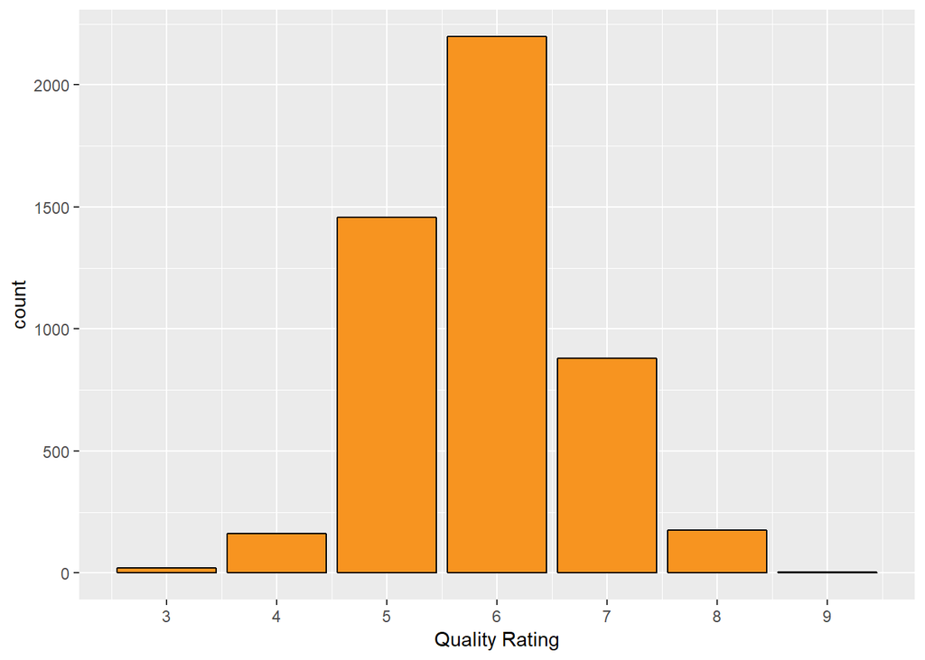

```
##    Min. 1st Qu.  Median    Mean 3rd Qu.    Max.
##   3.000   5.000   6.000   5.878   6.000   9.000
```

We can observe that the distribution of quality ratings appears to be normal, with the majority of the wines falling in the 5, 6 and 7 rating bins. Wines with a rating of 3 or 9 appear to be the lowest in number.

### 3b. Fixed Acidity

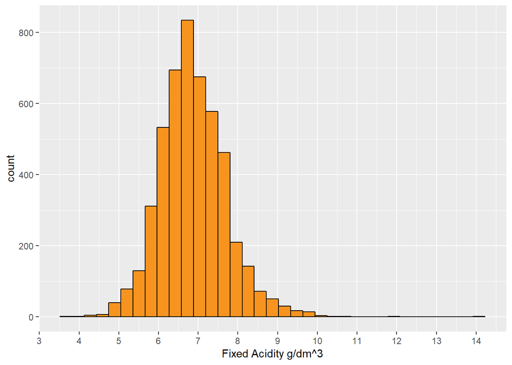

```
##    Min. 1st Qu.  Median    Mean 3rd Qu.    Max.
##   3.800   6.300   6.800   6.855   7.300  14.200
```

It appears that fixed acidity is slightly right skewed with a median of 6.8 g/dm<sup>3</sup> and a mean of 6.86 g/dm<sup>3</sup>. Most wines have a fixed acidity between 6 and 7.5 g/dm<sup>3</sup>. Outliers can be observed between 10 and 14.20 g/dm<sup>3</sup>.

### 3c. Volatile Acidity

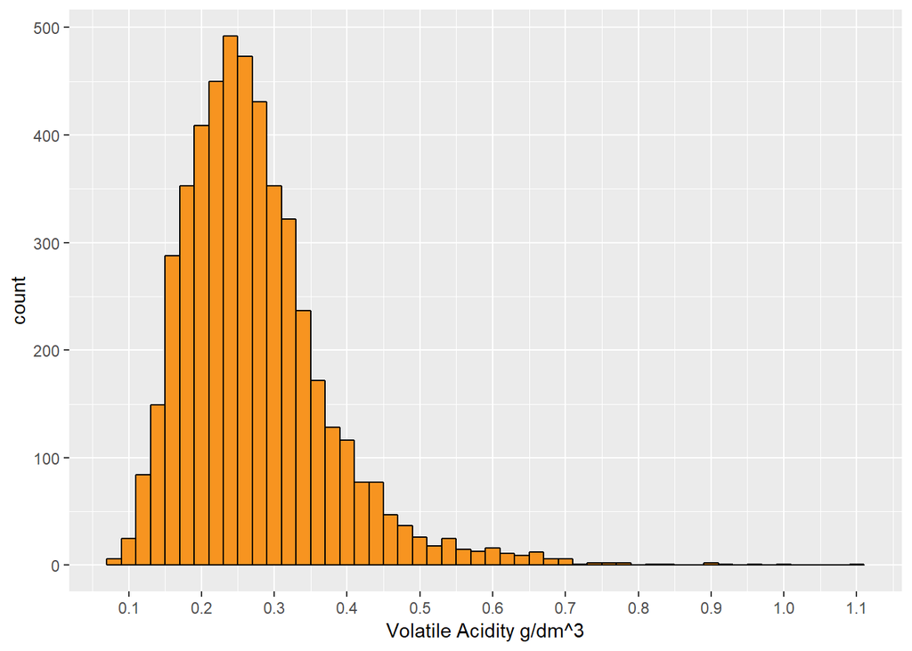

```
##    Min. 1st Qu.  Median    Mean 3rd Qu.    Max.
##  0.0800  0.2100  0.2600  0.2782  0.3200  1.1000
```

Volatile acidity seems to be right skewed with a median value of 0.26 and a mean of 0.28 g/dm<sup>3</sup>. The majority of observations fall between 0.21 and 0.32 g/dm<sup>3</sup>. The minimum value is 0.08 and maximum value is 1.1 g/dm<sup>3</sup>. There is a significant number of outliers above 0.4 g/dm<sup>3</sup>.

### 3d. Citric Acid

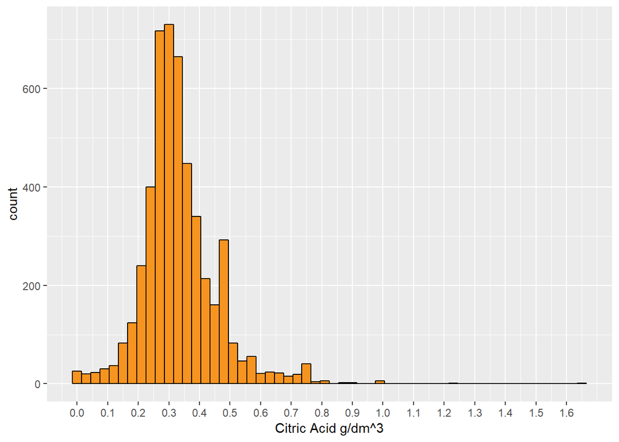

```
##    Min. 1st Qu.  Median    Mean 3rd Qu.    Max.
##  0.0000  0.2700  0.3200  0.3342  0.3900  1.6600
```

Citric acid appears to be right skewed and normally distributed with a median of 0.32 g/dm<sup>3</sup> and a mean of 0.33 g/dm<sup>3</sup>. There is a sharp increase in the number of white wineswith a Citric Acid measure of 0.47 g/dm<sup>3</sup>, which could be interesting for future analyses. There are numerous outliers past the 3rd Quartile, with a maximum value of 1.66 g/dm<sup>3</sup>.

### 3e. Residual Sugar

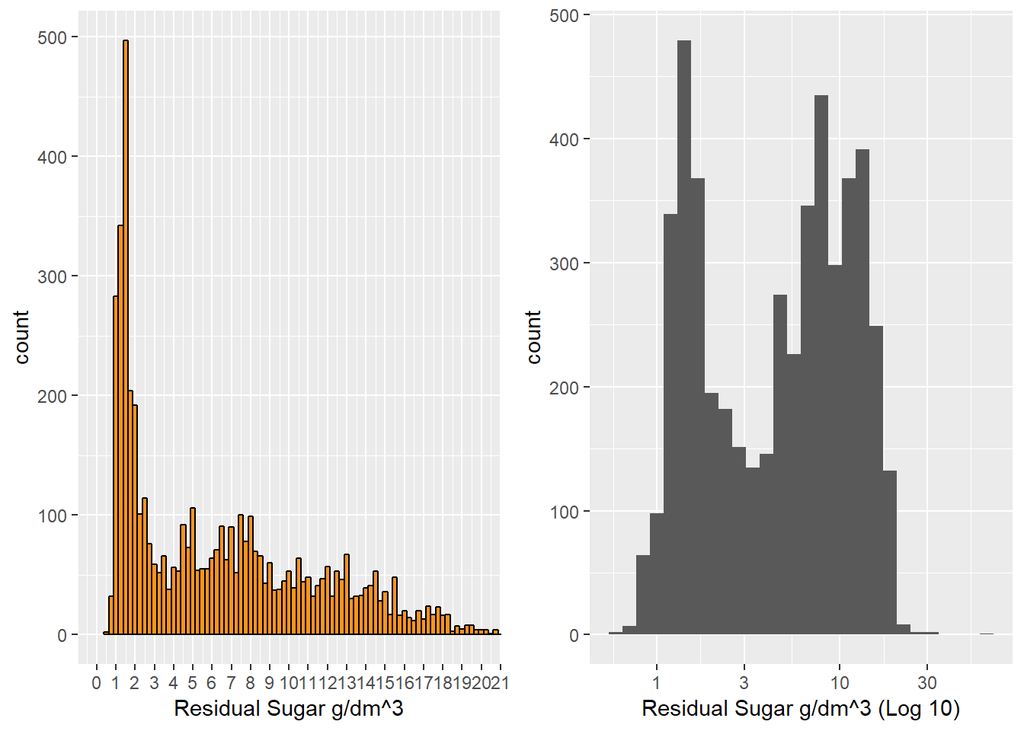

```
##    Min. 1st Qu.  Median    Mean 3rd Qu.    Max.
##   0.600   1.700   5.200   6.391   9.900  65.800
```

The plot for residual sugar shows a large right skew with a long tail. The highest peaks are between 1 and 1.6 g/dm<sup>3</sup>. The plot had to be limited to 20 g/dm<sup>3</sup> due to the large number of outliers, with a maximum value reaching 65 g/dm<sup>3</sup>.

Due to the large right skew, we will transform the plot using log 10. The result is a plot that appears to have a bi-modal distribution.

### 3f. Chlorides

[output not shown]

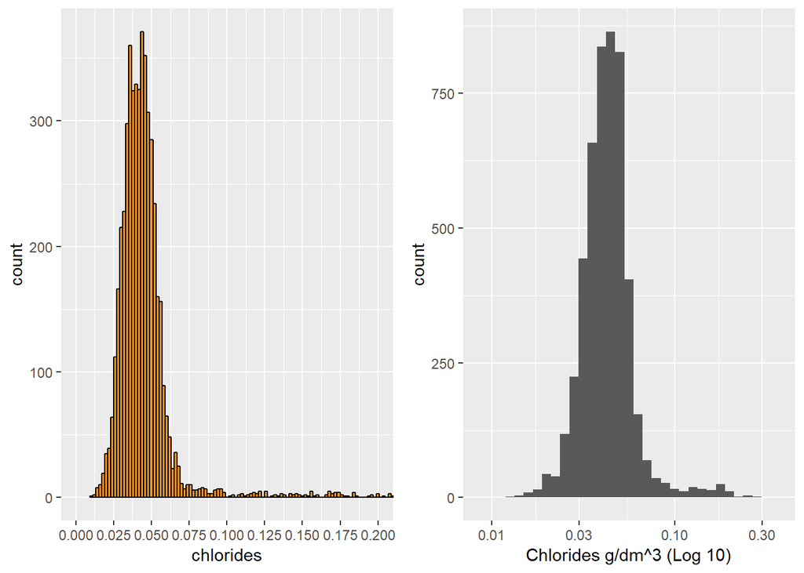

```
##    Min. 1st Qu.  Median    Mean 3rd Qu.    Max.
## 0.00900 0.03600 0.04300 0.04577 0.05000 0.34600
```

We can observe that the distribution for chlorides is right skewed with many outliers above the third quartile of 0.05 g/dm<sup>3</sup>, with a maximum value of 0.35 g/dm<sup>3</sup>. However, most values fall between 0.035 and 0.05 g/dm<sup>3</sup>. By limiting the x-axis the distribution looks normal around the mean.

As in the case of residual sugar, we can also transform and view the plot using log 10 due to the higly skewed observations of this variable.

### 3g. Free Sulfur Dioxide

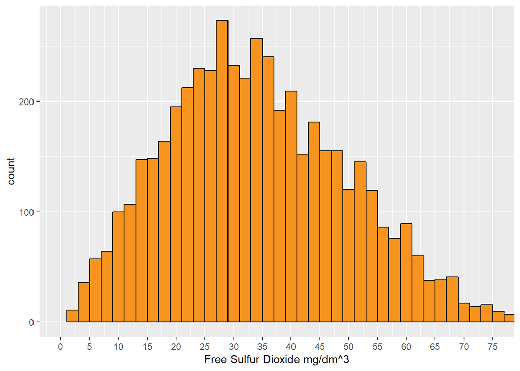

```
##    Min. 1st Qu.  Median    Mean 3rd Qu.    Max.
##    2.00   23.00   34.00   35.31   46.00  289.00
```

The distribution for free sulfur dioxide appears normally distributed with a right skew. Most wines have a sulfur dioxide concentration between 23 and 46 mg/dm<sup>3</sup>. There appears to be a large number of outliers, with a maximum value of 289 mg/dm<sup>3</sup>, therefore the scale has been limited to 75 mg/dm<sup>3</sup>. The median is 34 mg/dm<sup>3</sup> and the mean is 35.31 mg/dm<sup>3</sup>.

### 3h. Total Sulfur Dioxide

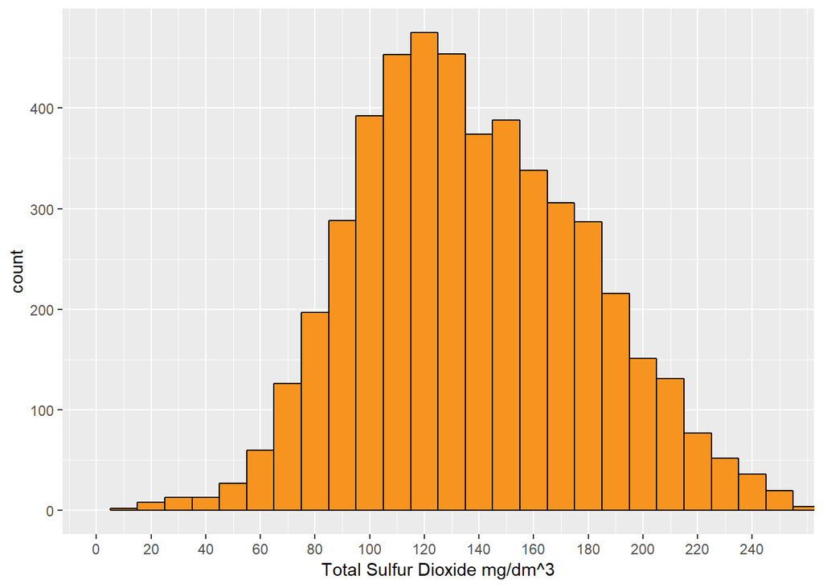

```
##    Min. 1st Qu.  Median    Mean 3rd Qu.    Max.
##     9.0   108.0   134.0   138.4   167.0   440.0
```

The distribution for total sulfur dioxide is nearly normal with a slight right skew. The median value is 134 mg/dm<sup>3</sup> and the mean is 138.4 mg/dm<sup>3</sup>. Most values lie between 108 mg/dm<sup>3</sup> and 167 mg/dm<sup>3</sup>. Again there are a lot of outliers with a maximum value of 440 mg/dm<sup>3</sup>.

### 3i. Density

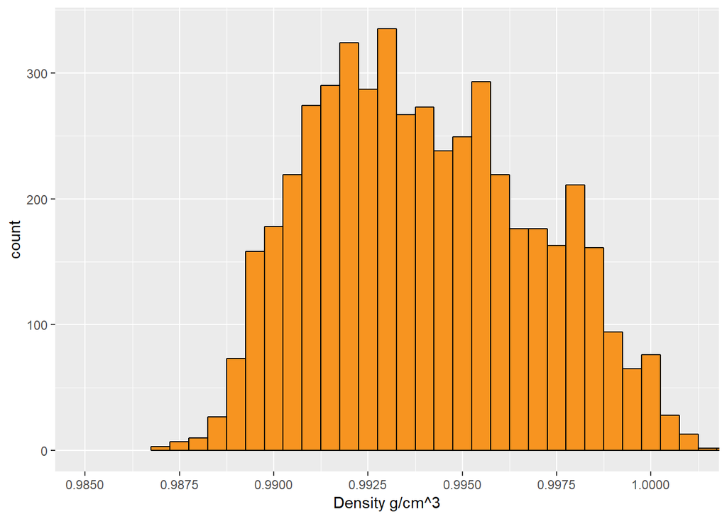

```
##    Min. 1st Qu.  Median    Mean 3rd Qu.    Max.
##  0.9871  0.9917  0.9937  0.9940  0.9961  1.0390
```

We can observe that density is almost normally distributed with a right skew. There are few outliers above the 3rd Quartile which is 0.9961 g/cm<sup>3</sup>. Density also has very little variation between values and the median is 0.9937 g/cm<sup>3</sup> while the mean is 0.9940 g/cm<sup>3</sup>. The maximum value is 1.039 g/cm<sup>3</sup>.

### 3j. pH

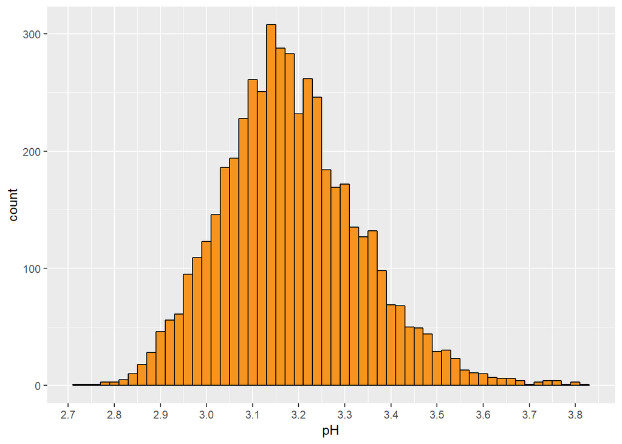

```
##    Min. 1st Qu.  Median    Mean 3rd Qu.    Max.
##   2.720   3.090   3.180   3.188   3.280   3.820
```

The pH feature is almost normally distributed with a mean of 3.188 and a median of 3.18, with a few outliers below and above the mean. The maximum value is 3.82.

### 3k. Sulphates

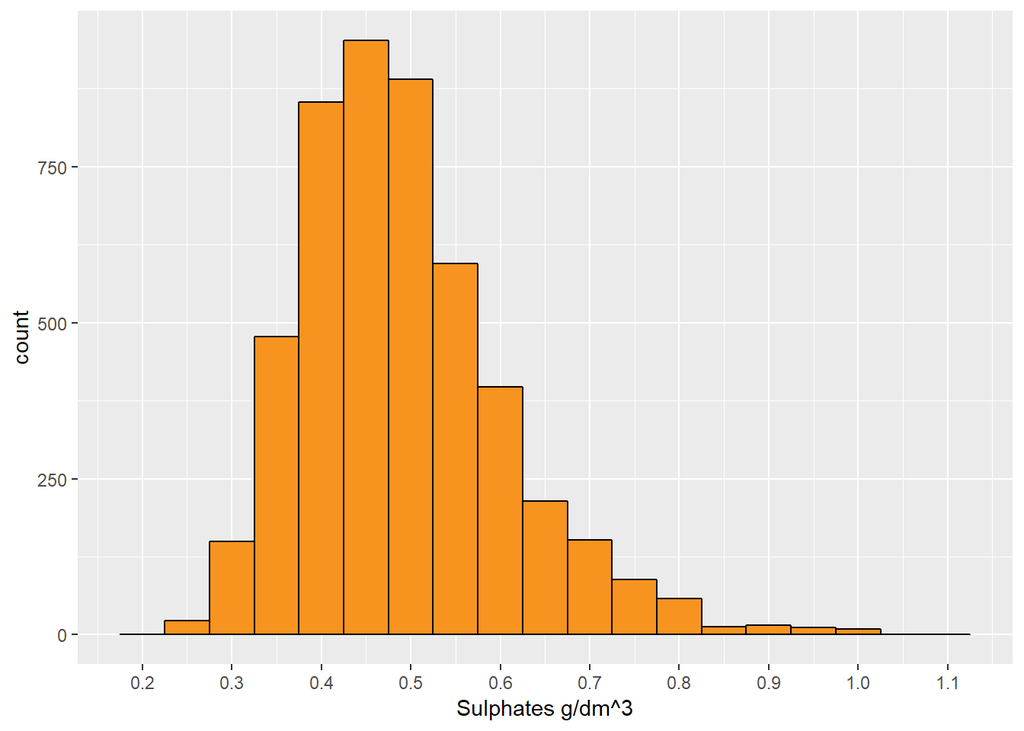

```
##    Min. 1st Qu.  Median    Mean 3rd Qu.    Max.
##  0.2200  0.4100  0.4700  0.4898  0.5500  1.0800
```

The distribution of sulphates is normal with a right skew. There are a few outliers above the mean of 0.4898, starting at about 0.8 g/dm<sup>3</sup>. The median is 0.47 g/dm<sup>3</sup> and the maximum value is 1.08 g/dm<sup>3</sup>.

### 3l. Alcohol

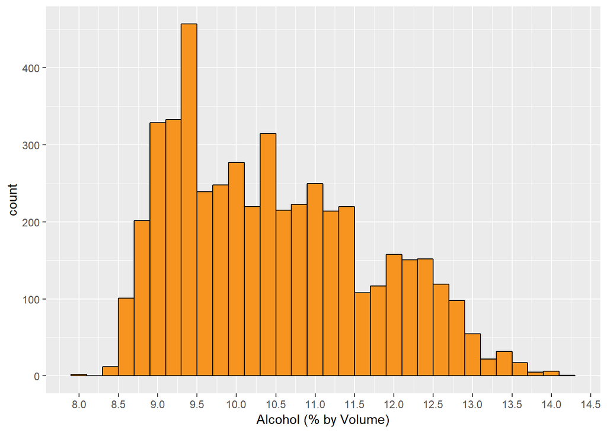

```
##    Min. 1st Qu.  Median    Mean 3rd Qu.    Max.
##    8.00    9.50   10.40   10.51   11.40   14.20
```

Here we can observe that the amount of alcohol by volume has a flatter distribution than other variables, though it retains a right skew. The peak of the distribution is at 9.35% and the range lies between 8% and 14.2% with a mean of 10.51% and a median of 10.40%. There are almost no outliers as well.

## 3m. Univariate Analysis

Following the univariate plotting, let’s delve deeper by answering some questions.

**Q1. What is the structure of your dataset?**

The dataset contains 4898 observations of 12 physicochemical variables. All of the features are numeric, and quality is a discrete variable that takes on the integers from 0 to 10.

**Q2. What is/are the main feature(s) of interest in your dataset?**

Quality is our mean feature of interest. It should be noted that most wines fall between 5 and 7 on the rating scale with 6 being the most frequent rating.

**Q3. What other features in the dataset do you think will help support your investigation into your feature(s) of interest?**

Based on some secondary research on wine quality, the variables of note are volatile acidity, fixed acidity, chlorides, alcohol and residual sugar, which may have an effect on the quality of wine.

**Q4. Did you create any new variables from existing variables in the dataset?**

No new variables were created from the existing data set.

**Q5. Of the features you investigated, were there any unusual distributions? Did you perform any operations on the data to tidy, adjust, or change the form of the data? If so, why did you do this?**

With regard to unusual distributions, I found that residual sugars, chlorides and alcohol content differred from the rest of the variables. Both residual sugars and chlorides had highly right-skewed distributions with large numbers of outliers. Alcohol was of interest as well due to its relatively flatter distribution.

There were minimal operations performed to tidy up the data since it is a curated data set. However, I did remove the observation numbering column and log conversions were carried out on plots for residual sugars and chlorides due to their skewness.

# 4. Bivariate Plots Section

We can now begin our bivariate analysis by first generating a scatter plot matrix and a correlation matrix to understand the relationships and correlations between variables.

In order to generate a scatterplot matrix, we will take a sample from the white wine data set. The statistical summary of the sample is:

```
##  fixed.acidity    volatile.acidity  citric.acid     residual.sugar
##  Min.   : 4.400   Min.   :0.0800   Min.   :0.0000   Min.   : 0.600
##  1st Qu.: 6.300   1st Qu.:0.2100   1st Qu.:0.2700   1st Qu.: 1.700
##  Median : 6.800   Median :0.2700   Median :0.3200   Median : 5.250
##  Mean   : 6.889   Mean   :0.2786   Mean   :0.3344   Mean   : 6.394
##  3rd Qu.: 7.400   3rd Qu.:0.3300   3rd Qu.:0.3800   3rd Qu.:10.062
##  Max.   :10.700   Max.   :1.1000   Max.   :1.0000   Max.   :26.050
##    chlorides       free.sulfur.dioxide total.sulfur.dioxide
##  Min.   :0.01400   Min.   :  3.00      Min.   : 18.0
##  1st Qu.:0.03600   1st Qu.: 22.00      1st Qu.:109.0
##  Median :0.04300   Median : 33.00      Median :136.0
##  Mean   :0.04625   Mean   : 34.49      Mean   :139.1
##  3rd Qu.:0.05000   3rd Qu.: 45.00      3rd Qu.:168.0
##  Max.   :0.34600   Max.   :138.50      Max.   :366.5
##     density             pH          sulphates         alcohol
##  Min.   :0.9871   Min.   :2.770   Min.   :0.2200   Min.   : 8.50
##  1st Qu.:0.9918   1st Qu.:3.090   1st Qu.:0.4100   1st Qu.: 9.50
##  Median :0.9938   Median :3.170   Median :0.4800   Median :10.30
##  Mean   :0.9941   Mean   :3.191   Mean   :0.4892   Mean   :10.48
##  3rd Qu.:0.9963   3rd Qu.:3.280   3rd Qu.:0.5400   3rd Qu.:11.30
##  Max.   :1.0030   Max.   :3.810   Max.   :0.9800   Max.   :14.00
##     quality
##  Min.   :3.000
##  1st Qu.:5.000
##  Median :6.000
##  Mean   :5.859
##  3rd Qu.:6.000
##  Max.   :9.000
```

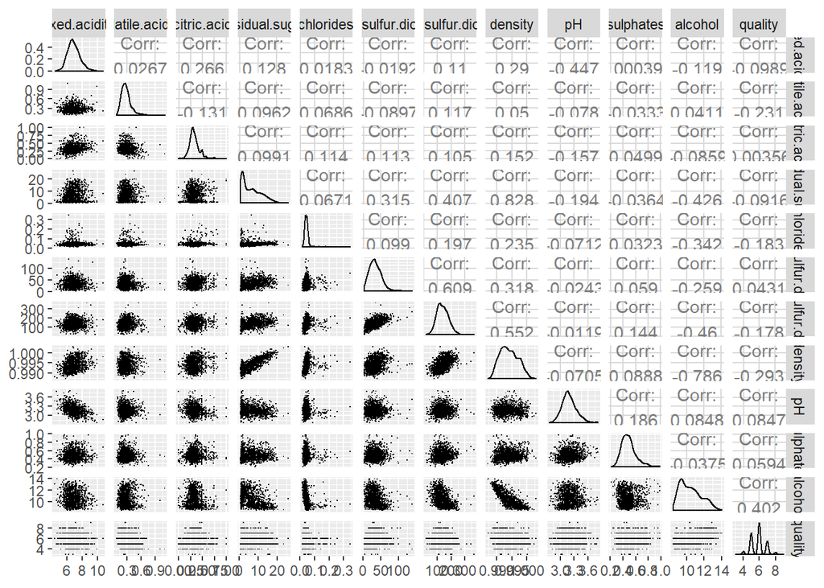

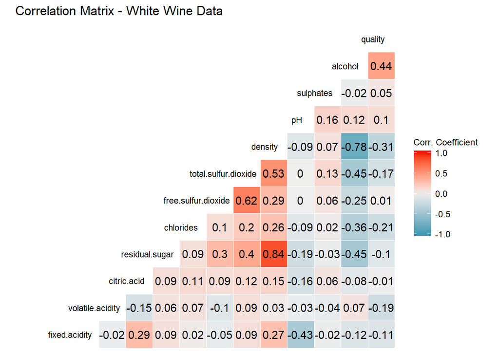

## 4a. Notable Correlations

Generating these two plots yields some very interesting observations with regard to the correlations between various variables:

1. As we know, quality is the feature of highest importance in our analysis and there is positive correlation with alcohol (0.44). However, none of the other variables show a strong positive correlation with quality. Alternatively, there are weak negative correlations with density (-0.31), chorides (-0.21) and volatile acidity (-0.19).
2. The strongest positive correlation in the data set, interestingly, is between density and residual sugar i.e. 0.84.
3. Other notable positive correlations are between density and total sulfur dioxide i.e. 0.53 and total sulfur dioxide and residual sugar i.e. 0.4.
4. The strongest negative correlation is between alcohol and density i.e. -0.78.
5. Notable negative correlations include alcohol and total sulfur dioxide i.e. -0.45, alcohol and chorides i.e. -0.36 and between alcohol and residual sugar i.e. -0.45. Also, pH and fixed acidity show a negative correlation of -0.43.

**Let us look at some plots which show the relationships between variables.**

### 4b. Density and Residual Sugar

Our most notable positive correlation is between density and residual sugar. Thus, we will generate a scatter plot to analyze their relationship.

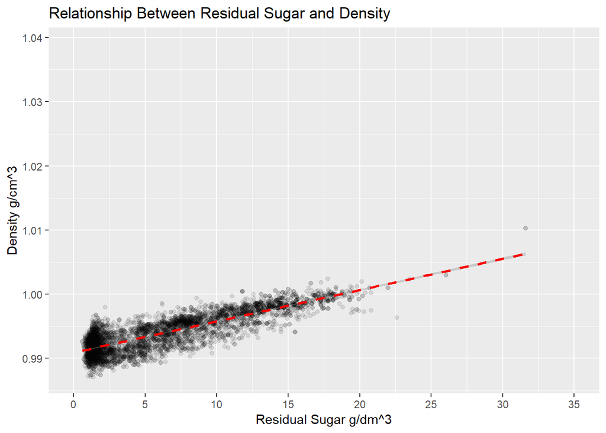

Here, the scatterplot shows a strong positive correlation. In other words, higher amounts of residual sugar result in greater white wine density.

### 4c. Density and Alcohol

The strongest negative correlation is between density and alcohol, so we shall plot the relationship.

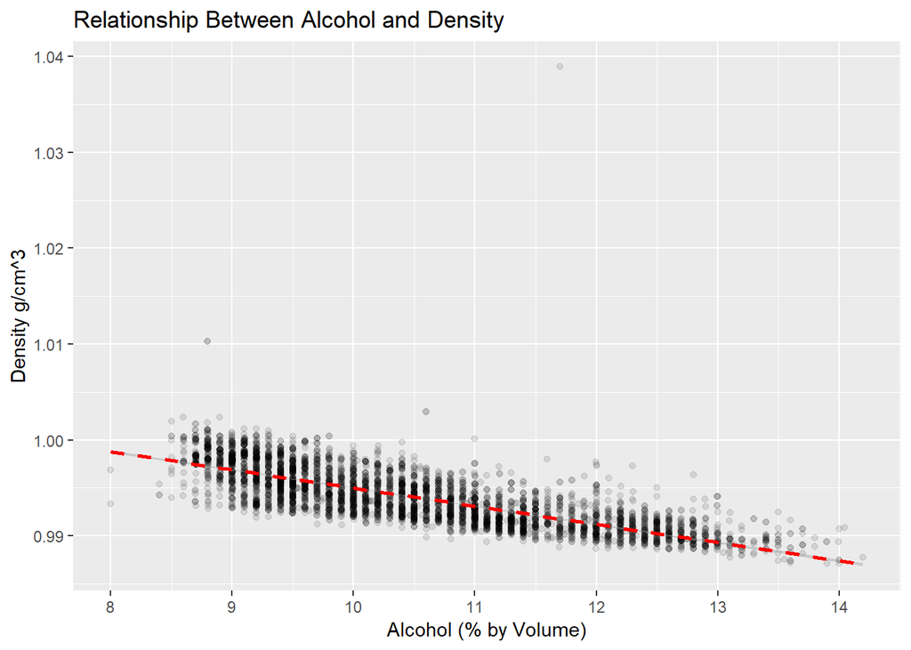

In this plot, we can observe a strong negative correlation between alcohol and density which means that wines with higher alcohol content will have lower densities and vice-versa.

**Now that we have plotted our strongest correlations, it is time to move on to our variable of interest i.e. quality and it’s relationship with variables which we highlighted in earlier sections.**

### 4e. Relationship of Quality with Alcohol, Chlorides, Density and Acidity

Let’s plot the various bivariate relationships quality has with variables highlighted earlier.

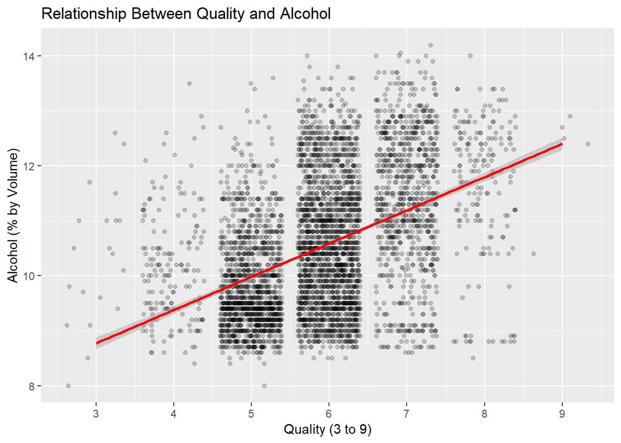

This plot indicates that higher quality wines contain higher quantities of alcohol content.

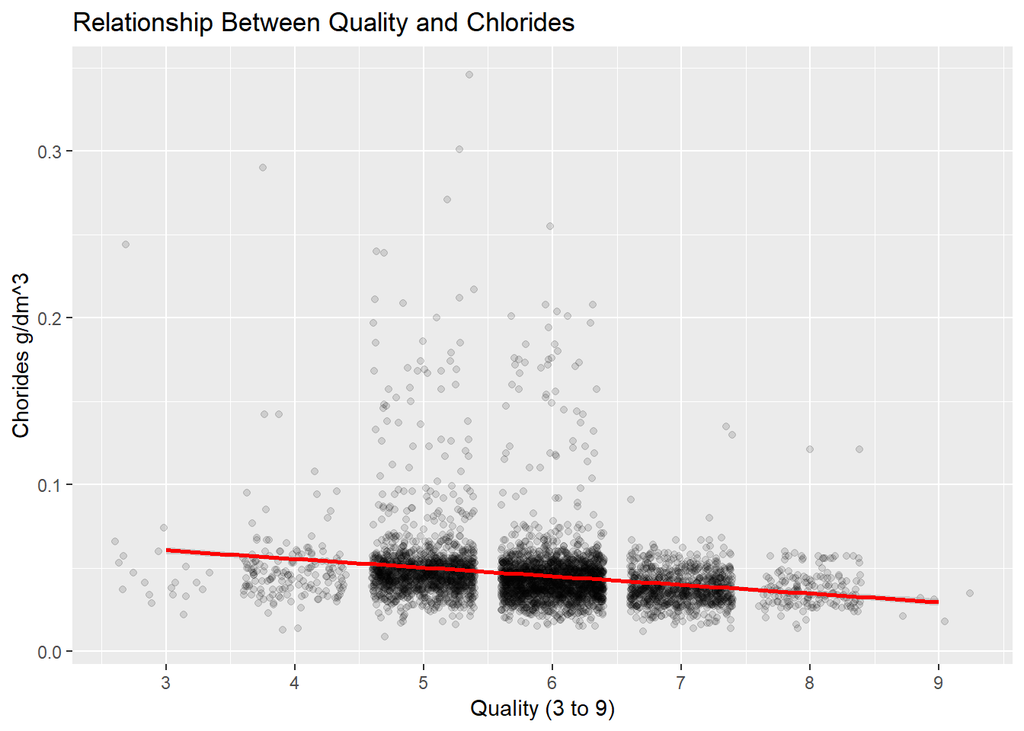

Here, we can see from the relatively weak negative correlation, that lower quality wines have higher amounts of chlorides in them.

[figure not shown]

Though there appears to be a weak negative correlation between quality and density, it can be assumed that higher rated wines have lower densities. Though, larger data sets and further experimentation can yield better results.

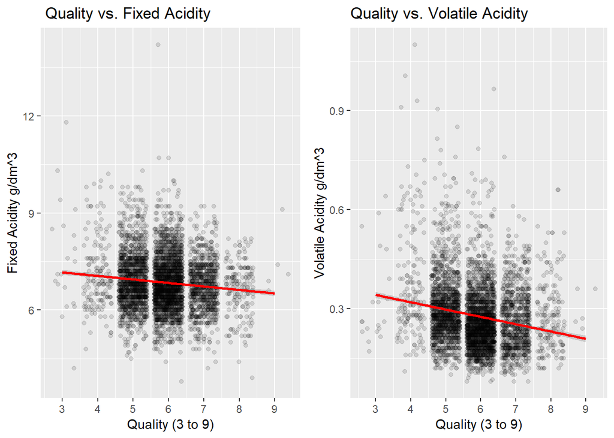

In the grid above, we can see that there is a weaker negative correlation between quality and fixed acidity as compared to quality and volatile acidity. But, in general, higher quality wines have lower levels of acidity.

### 4f. Relationship Between Variables with Notable Correlations

Let us also look at relationships between variables which exhibited notable correlations.

First, we shall look at the relationshop between pH and fixed acidity.

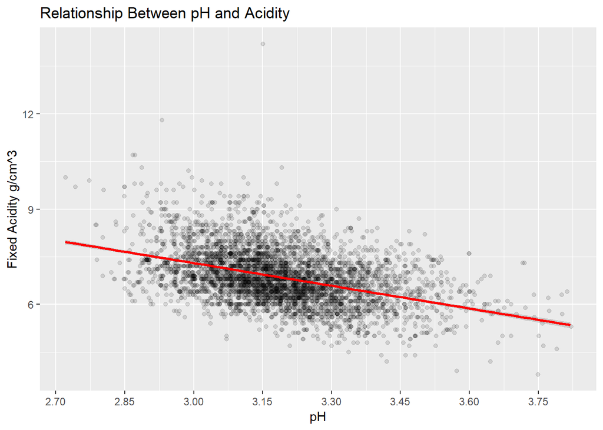

It can be observed that wines with higher pH values have lower fixed acidity, making for a moderately negative correlation.

Referring to the correlation matrix, we shall analyze alcohol’s relationship with sulfur dioxide, chorides and residual sugars.

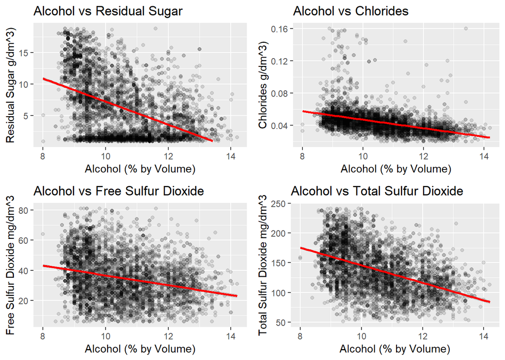

Here, we used a limiter to drop 1 percentage point from the top and bottom quantiles in order to filter outliers. The result is that alcohol has negative correlations with residual sugar, chlorides and both free and total sulfur dioxide. Of these, residual sugar shows a stronger negative correlation.

# 4g. Bivariate Analysis

**Q1. Talk about some of the relationships you observed in this part of the investigation. How did the feature(s) of interest vary with other features in the dataset?**

It should be noted that while quality was our feature of interest, it did not show strong positive or negative correlations with any of the other features / variables. The most notable positive correlation was with alcohol, while the most notable negative correlation was with density.

Other features, such as density, total sulfur dioxide and residual sugar had much stronger positive and negative correlations between them. This would suggest that the chemical make-up of a wine has more measurable relationships between its various components when compared to a purely subjective measure such as quality ratings.

**Q2. Did you observe any interesting relationships between the other features (not the main feature(s) of interest)?**

It is interesting to note that alcohol and residual sugars have a negative correlation. This could indicate that higher alcohol content has fewer “waste” sugars in the finished product. Also, the negative relationship between pH and fixed acidity stood out as well.

**Q3. What was the strongest relationship you found?**

The strongest relationships in the data set exist between density and residual sugar, with a positive correlation of 0.84.

# 5. Multivariate Plots Section

Let us now move onto the meat of the report i.e. the multivariate analysis. Here, we will look at the relationships of 2 or more variables with the feature of interest i.e. quality.

### 5a. Quality with Residual Sugar and Density

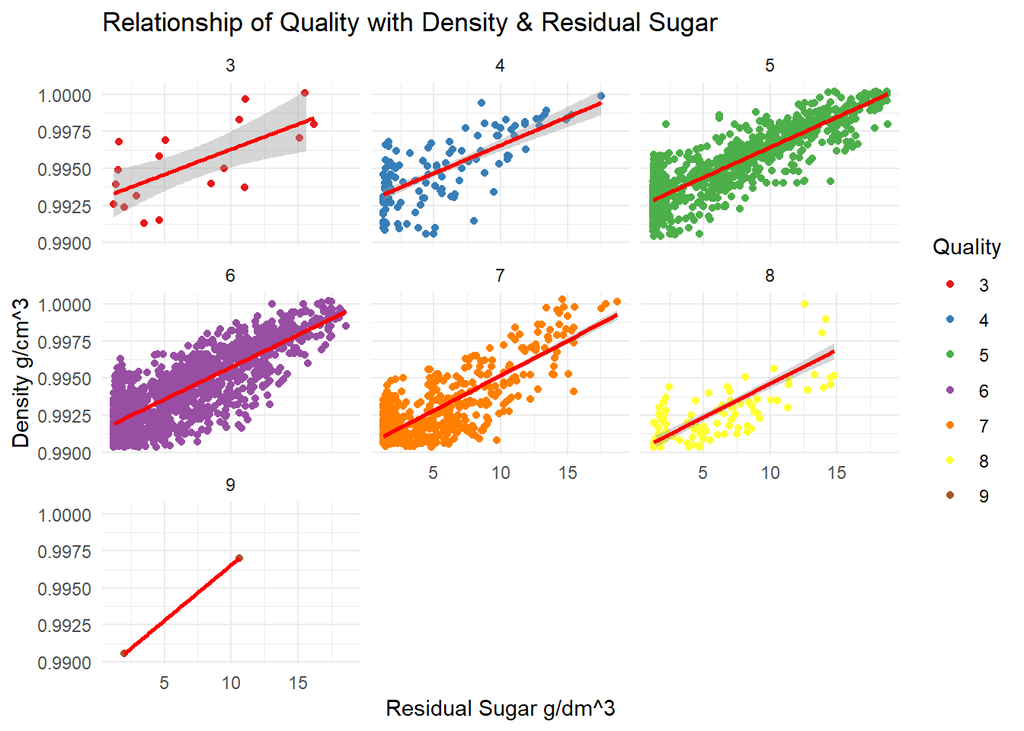

In this first multivariate plot, we will use facet wrap to help us dive deeper into the relatrionship of density and residual sugar with quality. 1 percent of observations from the top and bottom quantiles have also been dropped to increase the plot’s readability. The result is a plot which shows a clearly positive relationship between density and residual sugar at all quality ratings. The clustering also suggests that wines with higher ratings have lower amounts of residual sugars and lower densities.

### 5b. Quality with Density and Alcohol

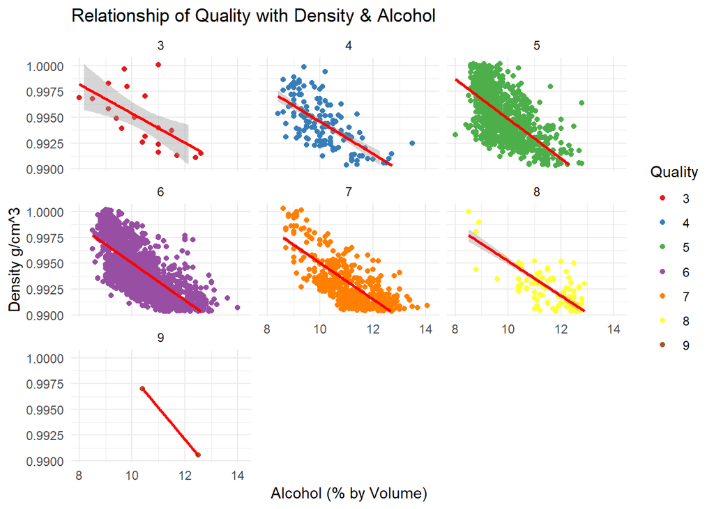

Here, the previous analysis of the negatively correlated relatioship between density and alcohol holds true across the quality ratings for white wines. The clustering of the observations also indicates thye higher amount of alcohol content and lower densities of wines with higher ratings. Though, it would be better to conduct further studies of wines with higher ratings to get additional observations which, in turn, will help us develop better models.

### 5c. Quality with pH and Fixed Acidity

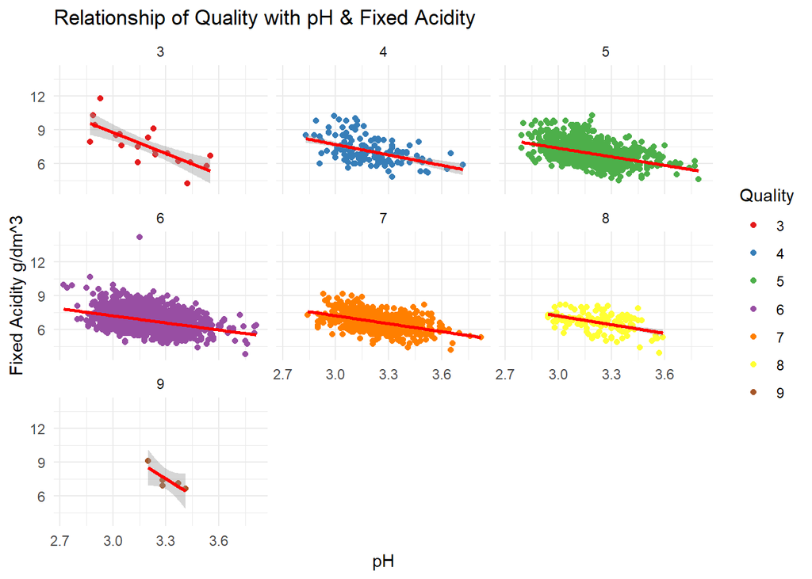

### 5d. Quality with Alcohol and Total Sulfur Dioxide

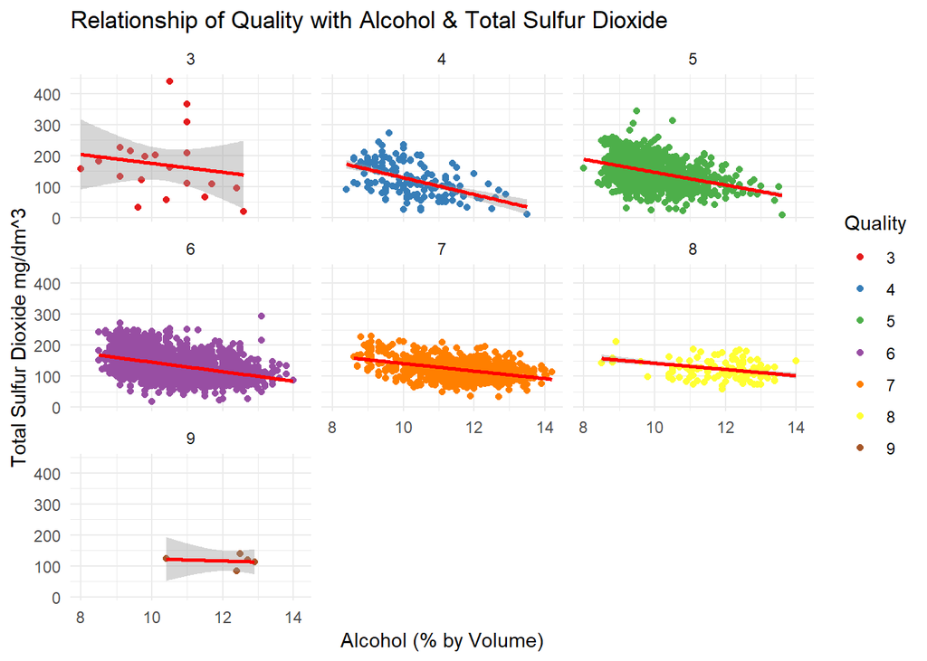

### 5e. Quality with Alcohol and Chlorides

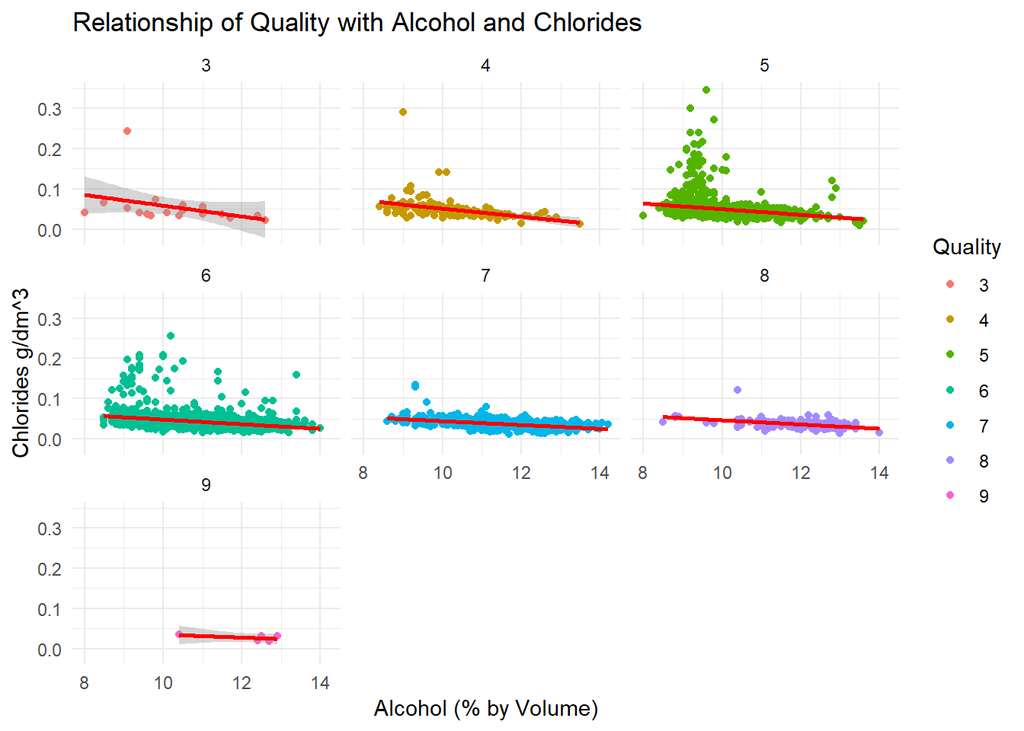

## 5f. Analysis Using Linear Regression Model

We will attempt to gain even more insight by building linear regression models which predict quality of wine wines using various predictors. The model will be updated accordingly:

### Base Model

```
##
## Call:
## lm(formula = quality ~ alcohol, data = wine)
##
## Residuals:
##     Min      1Q  Median      3Q     Max
## -3.5317 -0.5286  0.0012  0.4996  3.1579
##
## Coefficients:
##             Estimate Std. Error t value Pr(>|t|)
## (Intercept) 2.582009   0.098008   26.34   <2e-16 ***
## alcohol     0.313469   0.009258   33.86   <2e-16 ***
## ---
## Signif. codes:  0 '***' 0.001 '**' 0.01 '*' 0.05 '.' 0.1 ' ' 1
##
## Residual standard error: 0.7973 on 4896 degrees of freedom
## Multiple R-squared:  0.1897, Adjusted R-squared:  0.1896
## F-statistic:  1146 on 1 and 4896 DF,  p-value: < 2.2e-16
```

### Expanded Model

```
##
## Calls:
## lm1: lm(formula = quality ~ alcohol, data = wine)
## lm2: lm(formula = quality ~ alcohol + fixed.acidity, data = wine)
## lm3: lm(formula = quality ~ alcohol + fixed.acidity + volatile.acidity,
##     data = wine)
## lm4: lm(formula = quality ~ alcohol + fixed.acidity + volatile.acidity +
##     citric.acid, data = wine)
## lm5: lm(formula = quality ~ alcohol + fixed.acidity + volatile.acidity +
##     citric.acid + residual.sugar, data = wine)
## lm6: lm(formula = quality ~ alcohol + fixed.acidity + volatile.acidity +
##     citric.acid + residual.sugar + chlorides, data = wine)
## lm7: lm(formula = quality ~ alcohol + fixed.acidity + volatile.acidity +
##     citric.acid + residual.sugar + chlorides + free.sulfur.dioxide,
##     data = wine)
## lm8: lm(formula = quality ~ alcohol + fixed.acidity + volatile.acidity +
##     citric.acid + residual.sugar + chlorides + free.sulfur.dioxide +
##     density, data = wine)
## lm9: lm(formula = quality ~ alcohol + fixed.acidity + volatile.acidity +
##     citric.acid + residual.sugar + chlorides + free.sulfur.dioxide +
##     density + pH, data = wine)
## lm10: lm(formula = quality ~ alcohol + fixed.acidity + volatile.acidity +
##     citric.acid + residual.sugar + chlorides + free.sulfur.dioxide +
##     density + pH + sulphates, data = wine)
## lm11: lm(formula = quality ~ alcohol + fixed.acidity + volatile.acidity +
##     citric.acid + residual.sugar + chlorides + free.sulfur.dioxide +
##     density + pH + sulphates + total.sulfur.dioxide, data = wine)
##
## ==================================================================================================================================================================================
##                             lm1           lm2           lm3           lm4           lm5           lm6           lm7           lm8           lm9           lm10          lm11
## ----------------------------------------------------------------------------------------------------------------------------------------------------------------------------------
##   (Intercept)               2.582***      3.084***      3.548***      3.538***      2.919***      3.036***      2.792***     50.901***    119.764***    152.979***    150.193***
##                            (0.098)       (0.143)       (0.141)       (0.142)       (0.150)       (0.164)       (0.169)      (13.760)      (17.726)      (18.439)      (18.804)
##   alcohol                   0.313***      0.308***      0.319***      0.319***      0.370***      0.362***      0.369***      0.313***      0.231***      0.193***      0.193***
##                            (0.009)       (0.009)       (0.009)       (0.009)       (0.010)       (0.011)       (0.011)       (0.019)       (0.024)       (0.024)       (0.024)
##   fixed.acidity                          -0.065***     -0.068***     -0.072***     -0.074***     -0.076***     -0.067***     -0.042**       0.043*        0.066**       0.066**
##                                          (0.014)       (0.013)       (0.014)       (0.014)       (0.014)       (0.014)       (0.015)       (0.021)       (0.021)       (0.021)
##   volatile.acidity                                     -1.988***     -1.975***     -2.119***     -2.093***     -2.030***     -1.994***     -1.917***     -1.880***     -1.863***
##                                                        (0.109)       (0.111)       (0.110)       (0.111)       (0.111)       (0.112)       (0.112)       (0.112)       (0.114)
##   citric.acid                                                         0.077        -0.004         0.018        -0.022        -0.005         0.045         0.019         0.022
```

[output cut: 12 more lines]

```
##                                                                                                                                                          (0.100)       (0.100)
##   total.sulfur.dioxide                                                                                                                                                 -0.000
##                                                                                                                                                                        (0.000)
## ----------------------------------------------------------------------------------------------------------------------------------------------------------------------------------
##   R-squared                 0.190         0.194         0.244         0.245         0.263         0.264         0.269         0.270         0.276         0.282         0.282
##   adj. R-squared            0.190         0.193         0.244         0.244         0.263         0.263         0.268         0.269         0.275         0.280         0.280
##   sigma                     0.797         0.796         0.770         0.770         0.760         0.760         0.758         0.757         0.754         0.751         0.751
##   F                      1146.395       587.228       527.729       395.927       349.998       292.329       256.613       226.580       207.083       191.738       174.344
##   p                         0.000         0.000         0.000         0.000         0.000         0.000         0.000         0.000         0.000         0.000         0.000
##   Log-likelihood        -5839.391     -5827.948     -5668.220     -5667.900     -5605.688     -5604.086     -5588.406     -5582.289     -5563.545     -5544.026     -5543.740
##   Deviance               3112.257      3097.748      2902.155      2901.776      2828.991      2827.141      2809.097      2802.090      2780.725      2758.651      2758.329
##   AIC                   11684.782     11663.895     11346.440     11347.800     11225.376     11224.171     11194.812     11184.579     11149.090     11112.053     11113.480
##   BIC                   11704.272     11689.881     11378.923     11386.780     11270.852     11276.144     11253.281     11249.545     11220.552     11190.012     11197.936
##   N                      4898          4898          4898          4898          4898          4898          4898          4898          4898          4898          4898
## ==================================================================================================================================================================================
```

We proceeded to fit our initial linear model with additional predictors from the data set, where some had higher positive / negative correlations than others. This model was built to determine whether the quality of white wine could be predicted based on the variables provided in the data set.

It can be observed that the R<sup>2</sup> values retain very low, despite the fitting of additional predictors to the model. Thus, we must assume that the model needs refinement after conducting further analyses and improving on the original data. In future studies, options other than linear regression must also be considered.

## 5g. Multivariate Analysis

*Talk about some of the relationships you observed in this part of the investigation. Were there features that strengthened each other in terms of looking at your feature(s) of interest?*

Through the course of the analysis, density and residual sugar consistently demonstrated the strength of their relationship with quality. Specifically, higher quality wines tend to have lower densities and lower residual sugars. Plus, alcohol content also showed a measurable relationship with quality, with higher quality wines consistently showing higher alcohol content by volume.

It was interesting to note that higher quality wines had relatively high pH values while exhibiting levels of fixed acidity which weren’t too different from other quality ratings.

*Were there any interesting or surprising interactions between features?*

The plot which featured the relationship of quality with alcohol and chlorides was interesting due to the distributions of chlorides in wines with ratings 5 and 6, especially at lower alcohol levels.

*Did you create any models with your dataset? Discuss the strengths and limitations of your model.*

The linear regression model created at the end of the multivariate analysis resulted in very low R<sup>2</sup> values, despite having been fitted with multiple predictors from the data set. This indicates that, besides linear regression, additional approaches to models need to be considered and further studies need to be conducted to identify additional predictors and features.

# 6. Final Plots and Summary

## 6a. Plot One

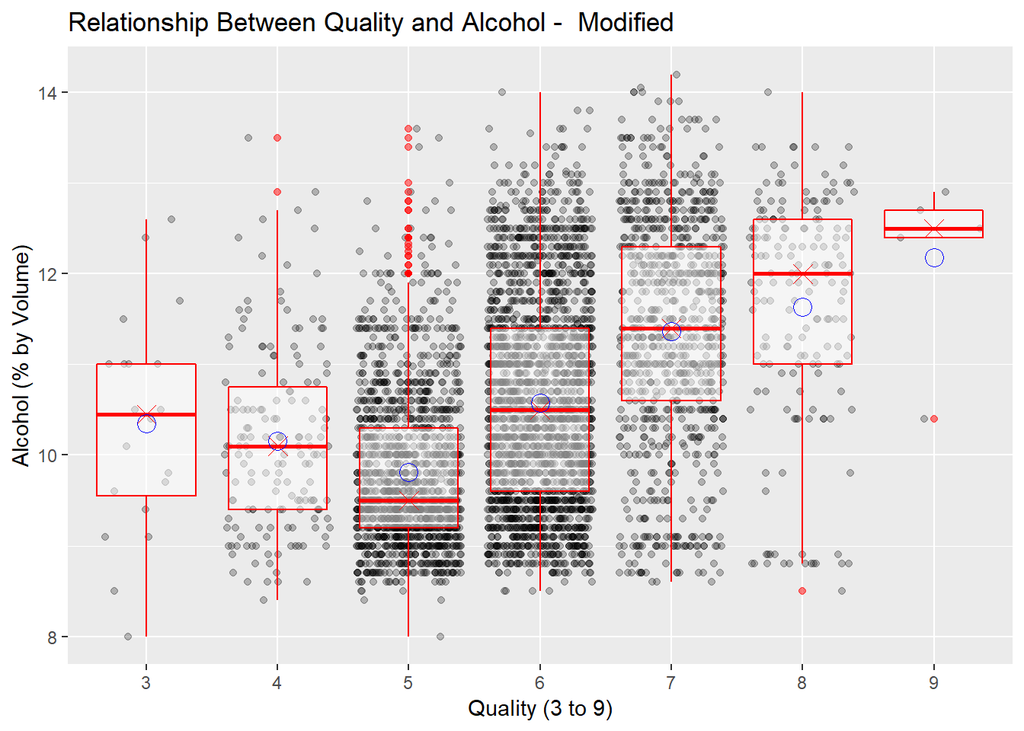

### Description:

The first plot, which shows the relationship between quality and alcohol by volume was chosen due to the fact that the two variables consistenly exhibited a relatively strong correlation throughout the analysis. The plot was further enhanced by an additional layer of box plots across the quality ratings. Mean and median values were also added as an additional feature

## 6b. Plot Two

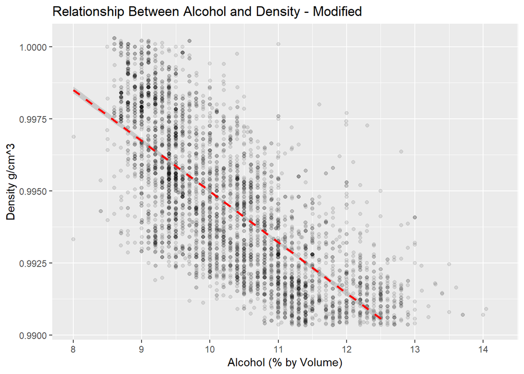

### Description Two:

THe second plot shows the relationship between alcohol and density. We already established that higher alcohol is correlated with lower density, with with a strong negative correlation. To get a better view of the distribution, 1 percentage point was dropped from the upper and lower quantiles of the y-axis i.e. density. This “zoomed in” view gives us a much better picture of the distribution, where the majority of observations lie between 8.6% and 11.5% alcohol by volume. In this range, density drops from 1.00 g/cm<sup>3</sup> to 0.9910 g/cm<sup>3</sup>.

## 6c. Plot Three

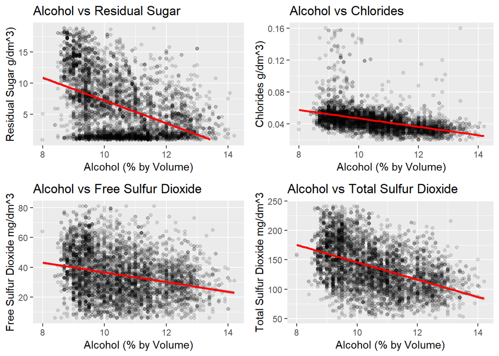

### Description Three

This plot grid was chosen because it shows alcohol’s relationship with key variables which showed notable correlations in the correlation matrix. These variables are residual sugar, chlorides, free and total sulfur dioxide. Of these, alcohol’s relationship with residual sugar and total sulfur dioxide is most notable and is characterized by a moderate negative correlation.

# 7. Reflection

From this exploratory data analysis, we observed that good wine tends to have higher alcohol levels, lower density, lower chlorides, volatile and fixed acidity and total sulfur dioxide. It was also shown that sugar, while a major ingredient in the wine maing process, has an inverse relationship with quality i.e. better or higher quality wines tend to have lower amounts of residual sugars. We must note that this analysis is based on correlation and does not imply causation between the features in the data set.

The biggest limitation of this analysis is that the data for white wines was generated for very specific white wines from a particular location in Europe. This may help us establish some sort of baseline for future analyses, but until data isn’t gathered from all wine producing regions of the world, this analysis can’t be considered robust.

In the future, I will attempt to use more advanced models, in addition to Machine Learning methodologies, to better analyse this data set.

# 8. References

1. P. Cortez, A. Cerdeira, F. Almeida, T. Matos and J. Reis. Modeling wine preferences by data mining from physicochemical properties. In Decision Support Systems, Elsevier, 47(4):547-553, 2009.
2. UCI Machine Learning Respository [Wine Quality Data Set](https://archive.ics.uci.edu/ml/datasets/wine+quality)
3. R-Statistics.com - log transformations for skewed data [link](https://www.r-statistics.com/2013/05/log-transformations-for-skewed-and-wide-distributions-from-practical-data-science-with-r/)
4. Statistical Tools for High-Throughput Data Analysis- GGPlot2 - Axis Scales and Transformations [link](http://www.sthda.com/english/wiki/ggplot2-axis-scales-and-transformations)
5. Statistical Tools for High-Throughput Data Analysis-GGally Correlation Matrix [Guide](http://www.sthda.com/english/wiki/ggally-r-package-extension-to-ggplot2-for-correlation-matrix-and-survival-plots-r-software-and-data-visualization)
6. Adventures in Statistics [blog](http://blog.minitab.com/blog/adventures-in-statistics-2/regression-analysis-how-do-i-interpret-r-squared-and-assess-the-goodness-of-fit)